# Activation Functions in Artificial Neural Networks

Johannes Lederer, *Ruhr-University Bochum

2021-01-23

This file contains software code and visualizations that accompany the paper

- Lederer, J. “Activation Functions in Artificial Neural Networks: A Systematic Overview.” *arXiv* (2021).

## Basic Definitions

We first define a framework for the visualizations.

### Activation Functions and Their Derivatives

We start by implementing the activation functions and their derivatives.

```r
# Section 2.1.1: logistic
FnLogistic <- function(z){
  return(1 / (1 + exp(-z)))
}
FnLogisticD <- function(z){
  logistic <- FnLogistic(z)
  return(logistic * (1 - logistic))
}
FnLogisticDD <- function(z){
  logistic <- FnLogistic(z)
  return(logistic * (1 - logistic) * (1 - 2 * logistic))
}
# Section 2.1.2: arctan
FnArctan <- function(z){
  return(atan(z))
}
FnArctanD <- function(z){
  return(1 / (1 + z^2))
}
FnArctanDD <- function(z){
  return(-2 * z / (1 + z^2)^2)
}
# Section 2.1.3: tanh
FnTanh <- function(z){
  return(tanh(z))
}
FnTanhD <- function(z){
  t <- FnTanh(z)
  return(1 - t^2)
}
FnTanhDD <- function(z){
  t <- FnTanh(z)
  return(-2 * t * (1 - t^2))
}
# Section 2.1.4: softsign
FnSoftsign <- function(z){
  return(z / (1 + abs(z)))
}
FnSoftsignD <- function(z){
  soft.abs <- abs(FnSoftsign(z))
  return((1 - soft.abs)^2)
}
FnSoftsignDD <- function(z){
  sg <- sign(z)
  soft.abs <- FnSoftsign(z)
  return(-2 * sg * (1 - soft.abs)^3)
}
# Section 2.2.1: linear
FnLinear <- function(z){
  return(z)
}
# Section 2.2.2: relu
FnRelu <- function(z){
  return(z * (z > 0))
}
# Section 2.2.3: leakyrelu
FnLeakyrelu <- function(z, a = 0.01){
  return(z * (z > 0) + a * z * (z < 0))
}
# Section 2.3.1: softplus
FnSoftplus <- function(z){
  return(log(1 + exp(z)))
}
FnSoftplusD <- function(z){
  return(FnLogistic(z))
}
FnSoftplusDD <- function(z){
  return(FnLogisticD(z))
}
# Section 2.3.2: elu
FnElu <- function(z, a = 1){
  # To avoid comp. of exp for z>=0
  # Note that ggplot evaluates the function for a vector,
  # which means that standard if ... else does not work
  ifelse(z >= 0, z, a * (exp(z) - 1))
}
# Section 2.3.3: swish
FnSwish <- function(z, a = 1){
  return(z * FnLogistic(a * z))
}
FnSwishD <- function(z, a = 1){
  swish <- a * FnSwish(z, a)
  logistic <- FnLogistic(a * z)
  return(swish + logistic * (1 - swish))
}
FnSwishDD <- function(z, a = 1){
  swish <- a * FnSwish(z, a)
  logistic <- FnLogistic(a * z)
  return(a * (swish + 2 * logistic * (1 - swish)) * (1 - logistic))
}
```

### Plotting Setup

We now set specifications for the plotting. (The `latex` switch yields specifications, which I use for the paper.)

```r
library(ggplot2)
LabXY <- function(latex = FALSE, derivative = FALSE){
  if (latex)
    if (derivative)
      return(c("$z$", "$f'[z]$"))
    else
      return(c("$z$", "$f[z]$"))
  else
    if (derivative)
      return(c("z", "f'[z]"))
    else
      return(c("z", "f[z]"))
}
LineSize <- function(latex = FALSE){
  if (latex)
    return(5)
  else
    return(1.5)
}
LabelFontSize <- function(latex = FALSE){
  if (latex)
    return(12)
  else
    return(4)
}
DashedLines <- function(latex = FALSE, legend = FALSE){
  if (latex)
    if (legend)
      return("BB")
    else
      return("FF")
  else
    if (legend)
      return("32")
    else
      return("44")
}
DottedLines <- function(latex = FALSE, legend = FALSE){
  if (latex)
    if (legend)
      return("1F")
    else
      return("6F")
  else
    if (legend)
      return("13")
    else
      return("13")
}
DotDashLines <- function(latex = FALSE, legend = FALSE){
  if (latex)
    if (legend)
      return("FF1F")
    else
      return("FF6F")
  else
    if (legend)
      return("3313")
    else
      return("4414")
}
```

## Comparisons Among Activation Functions

We now compare different activation functions.

### Broad Overview

We first give an overview of the ten main activation functions discussed in the paper (Figure 8 in the manuscript).

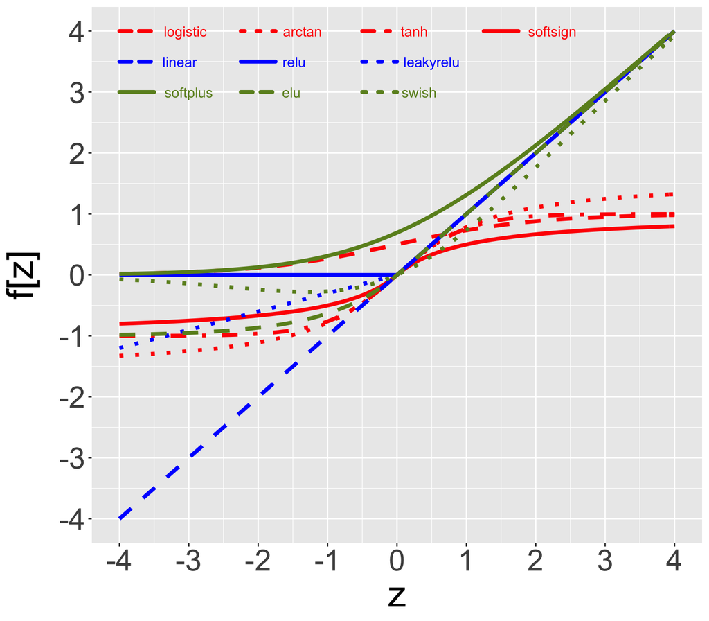

```r
data <- data.frame(x = c(-4,4))
PlotOverview <- function(latex = FALSE){
  ggplot() +
    stat_function(fun      = FnLogistic,
                  color    = "red",
                  size     = LineSize(latex),
                  linetype = DashedLines(latex, FALSE)) +
    geom_segment(aes(x = -4, y = 4, xend = -3.5, yend = 4),
                 color    = "red",
                 size     = LineSize(latex),
                 lineend  = "round",
                 linetype = DashedLines(latex, TRUE)) +
    annotate("text", x = -3.05, y = 4, color= "red", label = "logistic", size = LabelFontSize(latex)) +
    stat_function(fun      = FnArctan,
                  color    = "red",
                  size     = LineSize(latex),
                  linetype = DottedLines(latex, FALSE)) +
    geom_segment(aes(x = -2.25, y = 4, xend = -1.75, yend = 4),
                 color    = "red",
                 size     = LineSize(latex),
                 lineend  = "round",
                 linetype = DottedLines(latex, TRUE)) +
    annotate("text", x = -1.36, y = 4, color= "red", label = "arctan", size = LabelFontSize(latex)) +
    stat_function(fun      = FnTanh,
                  color    = "red",
                  size     = LineSize(latex),
                  linetype = DotDashLines(latex, FALSE)) +
    geom_segment(aes(x = -0.5, y = 4, xend = -0, yend = 4),
                 color    = "red",
                 size     = LineSize(latex),
                 lineend  = "round",
                 linetype = DotDashLines(latex, TRUE)) +
    annotate("text", x = 0.25, y = 4, color= "red", label = "tanh", size = LabelFontSize(latex)) +
    stat_function(fun      = FnSoftsign,
                  color    = "red",
                  size     = LineSize(latex),
                  linetype = "solid") +
    geom_segment(aes(x = 1.25, y = 4, xend = 1.75, yend = 4),
                 color    = "red",
                 size     = LineSize(latex),
                 lineend  = "round",
                 linetype = "solid") +
    annotate("text", x = 2.24, y = 4, color= "red", label = "softsign", size = LabelFontSize(latex)) +
    stat_function(fun      = FnLinear,
                  color    = "blue",
                  size     = LineSize(latex),
                  linetype = DashedLines(latex, FALSE)) +
    geom_segment(aes(x = -4, y = 3.5, xend = -3.5, yend = 3.5),
                 color    = "blue",
                 size     = LineSize(latex),
                 lineend  = "round",
                 linetype = DashedLines(latex, TRUE)) +
    annotate("text", x = -3.13, y = 3.5, color= "blue", label = "linear", size = LabelFontSize(latex)) +
    stat_function(fun      = FnRelu,
                  color    = "blue",
                  size     = LineSize(latex),
                  linetype = "solid") +
    geom_segment(aes(x = -2.25, y = 3.5, xend = -1.75, yend = 3.5),
                 color    = "blue",
                 size     = LineSize(latex),
                 lineend  = "round",
                 linetype = "solid") +
    annotate("text", x = -1.48, y = 3.5, color= "blue", label = "relu", size = LabelFontSize(latex)) +
    stat_function(fun      = function(z){FnLeakyrelu(z,a=0.3)},
                  color    = "blue",
                  size     = LineSize(latex),
                  linetype = DottedLines(latex, FALSE)) +
    geom_segment(aes(x = -0.5, y = 3.5, xend = -0, yend = 3.5),
                 color    = "blue",
                 size     = LineSize(latex),
                 lineend  = "round",
                 linetype = DottedLines(latex, TRUE)) +
    annotate("text", x = 0.5, y = 3.5, color= "blue", label = "leakyrelu", size = LabelFontSize(latex)) +
    stat_function(fun      = FnSoftplus,
                  color    = "olivedrab",
                  size     = LineSize(latex),
                  linetype = "solid") +
    geom_segment(aes(x = -4, y = 3, xend = -3.5, yend = 3),
                 color    = "olivedrab",
                 size     = LineSize(latex),
                 lineend  = "round",
                 linetype = "solid") +
    annotate("text", x = -3, y = 3, color= "olivedrab", label = "softplus", size = LabelFontSize(latex)) +
    stat_function(fun      = FnElu,
                  color    = "olivedrab",
                  size     = LineSize(latex),
                  linetype = DashedLines(latex, FALSE)) +
    geom_segment(aes(x = -2.25, y = 3, xend = -1.75, yend = 3),
                 color     = "olivedrab",
                 size      = LineSize(latex),
                 lineend   = "round",
                 linetype = DashedLines(latex, TRUE)) +
    annotate("text", x = -1.52, y = 3, color= "olivedrab", label = "elu", size = LabelFontSize(latex)) +
    stat_function(fun      = FnSwish,
                  color    = "olivedrab",
                  size     = LineSize(latex),
                  linetype = DottedLines(latex, FALSE)) +
    geom_segment(aes(x = -0.5, y = 3, xend = -0, yend = 3),
                 color    = "olivedrab",
                 size     = LineSize(latex),
                 lineend  = "round",
                 linetype =  DottedLines(latex, TRUE)) +
    annotate("text", x = 0.32, y = 3, color= "olivedrab", label = "swish", size = LabelFontSize(latex)) +
    scale_x_continuous(breaks = c(-4, -3, -2, -1, 0, 1, 2, 3, 4),
                       limits = c(-4, 4)) +
    scale_y_continuous(breaks = c(-4, -3, -2, -1, 0, 1, 2, 3, 4),
                       limits = c(-4, 4)) +
    labs(x = LabXY(latex = latex)[1],
         y = LabXY(latex = latex)[2]) +
    theme(text = element_text(size = 30)) +
    theme(axis.title.y = element_text(margin = margin(t = 0, r = 15, b = 0, l = 0))) +
    theme(legend.position = c(0.8, 0.2))
}
PlotOverview()
```

### Sigmoid Functions

We now compare the sigmoid functions among each other (Figure 2 in the manuscript).

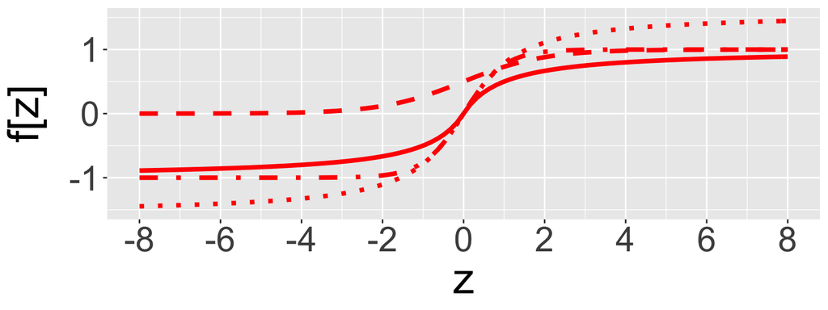

```r
PlotSigmoid <- function(latex = FALSE, FUN1 = FnLogistic, FUN2 = FnArctan, FUN3 = FnTanh, FUN4 = FnSoftsign, derivative = FALSE){
  ggplot() +
    stat_function(fun      = FUN1,
                  color    = "red",
                  size     = LineSize(latex),
                  linetype = DashedLines(latex)) +
    stat_function(fun      = FUN2,
                  color    = "red",
                  size     = LineSize(latex),
                  linetype = DottedLines(latex)) +
    stat_function(fun      = FUN3,
                  color    = "red",
                  size     = LineSize(latex),
                  linetype = DotDashLines(latex)) +
    stat_function(fun      = FUN4,
                  color    = "red",
                  size     = LineSize(latex),
                  linetype = "solid") +
    scale_x_continuous(breaks = c(-8, -6, -4, -2, 0, 2, 4, 6, 8),
                       limits = c(-8, 8)) +
    scale_y_continuous(breaks = c(-1, 0, 1),
                       limits = c(-1.5, 1.5)) +
    labs(x = LabXY(latex      = latex,
                   derivative = derivative)[1],
         y = LabXY(latex      = latex,
                   derivative = derivative)[2]) +
    theme(text = element_text(size = 30)) +
    theme(axis.title.y = element_text(margin = margin(t = 0, r = 15, b = 0, l = 0)))
}
PlotSigmoid()
```

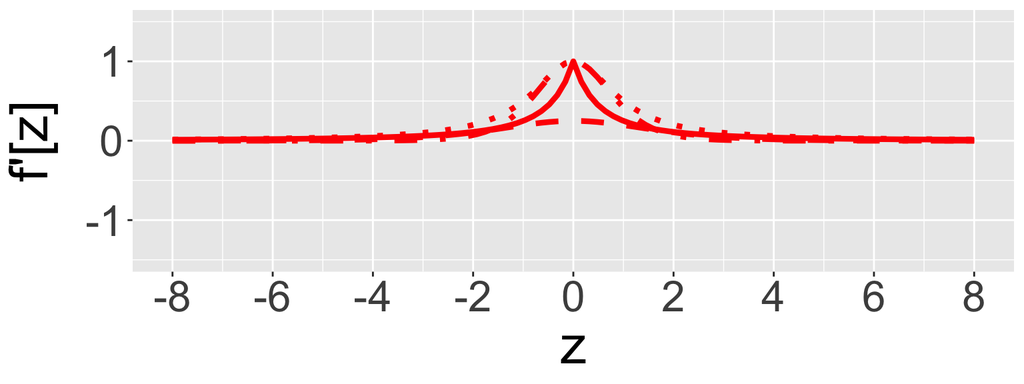

```r
PlotSigmoid(FUN1 = FnLogisticD, FUN2 = FnArctanD, FUN3 = FnTanhD, FUN4 = FnSoftsignD, derivative = TRUE)
```

### Logistic Sigmoid Function Versus Binary Step Function

We now support the interpretation of logistic as a smooth step function (Figure 3 in the manuscript).

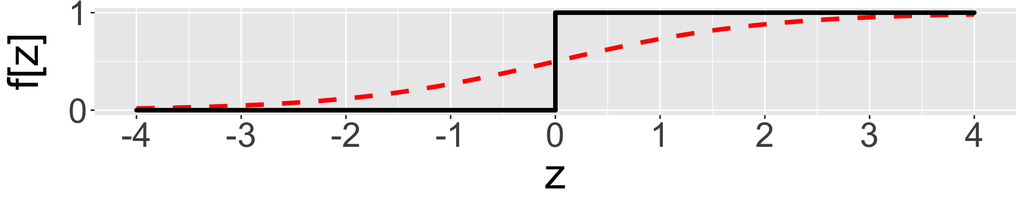

```r
PlotLogStep <- function(latex = FALSE){
  ggplot() +
    stat_function(fun      = FnLogistic,
                  color    = "red",
                  size     = LineSize(latex),
                  linetype = DashedLines(latex)) +
    geom_segment(aes(x = -4, y = 0, xend = 0, yend = 0),
                 color    = "black",
                 size     = LineSize(latex),
                 lineend  = "round",
                 linetype = "solid") +
    geom_segment(aes(x = 0, y = 0, xend = 0, yend = 1),
                 color    = "black",
                 size     = LineSize(latex),
                 lineend  = "round",
                 linetype = "solid") +
    geom_segment(aes(x = 0, y = 1, xend = 4, yend = 1),
                 color    = "black",
                 size     = LineSize(latex),
                 lineend  = "round",
                 linetype = "solid") +
  scale_x_continuous(breaks = c(-4, -3, -2, -1, 0, 1, 2, 3, 4),
                     limits = c(-4, 4)) +
  scale_y_continuous(breaks = c(0, 1),
                     limits = c(0, 1)) +
  labs(x = LabXY(latex = latex)[1],
       y = LabXY(latex = latex)[2]) +
  theme(text = element_text(size = 30)) +
  theme(axis.title.y = element_text(margin = margin(t = 0, r = 15, b = 0, l = 0)))
}
PlotLogStep()
```

### Arctan Versus Tanh Around 0

We now illustrate that arctan and tanh are very similar around the origin (Figure 4 in the manuscript).

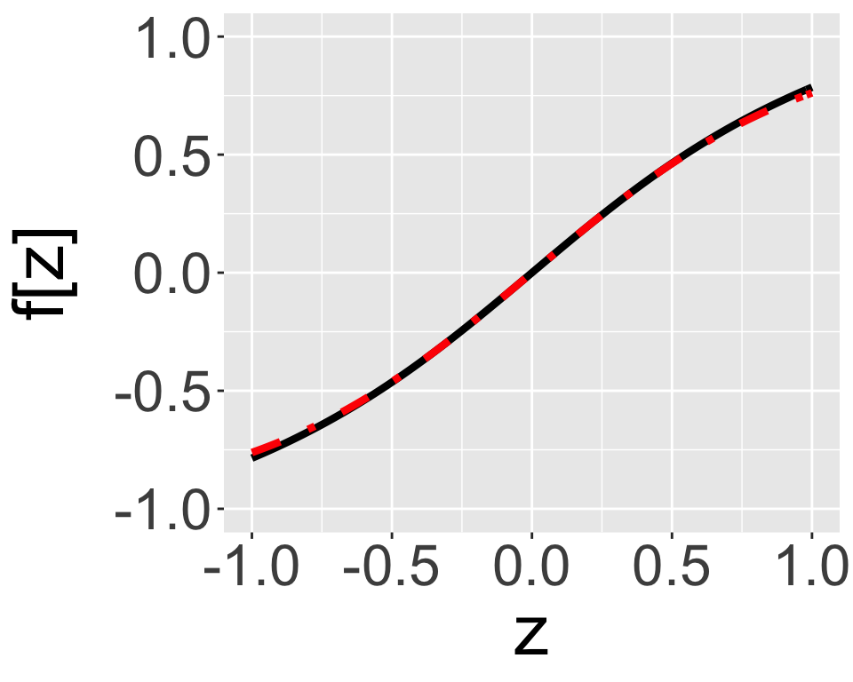

```r
PlotArctanTanh <- function(latex = FALSE){
  ggplot() +
    stat_function(fun      = FnArctan,
                  color    = "black",
                  size     = LineSize(latex),
                  linetype = "solid") +
    stat_function(fun      = FnTanh,
                  color    = "red",
                  size     = LineSize(latex),
                  linetype = DotDashLines(latex)) +
    scale_x_continuous(breaks = c(-1, -0.5, 0, 0.5, 1),
                       limits = c(-1, 1)) +
    scale_y_continuous(breaks = c(-1, -0.5, 0, 0.5, 1),
                       limits = c(-1, 1)) +
    labs(x = LabXY(latex)[1], y = LabXY(latex)[2]) +
    theme(text = element_text(size = 30)) +
    theme(axis.title.y = element_text(margin = margin(t = 0, r = 15, b = 0, l = 0)))
}
PlotArctanTanh()
```

### Softplus Versus Relu

We now support the interpretation of softplus as a smooth version of relu (Figure 5 in the manuscript).

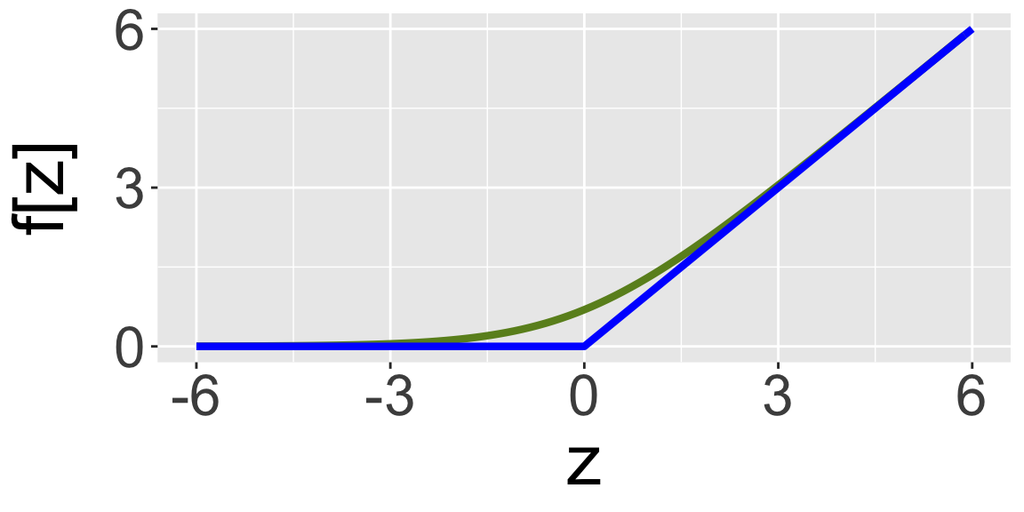

```r
PlotSoftplusRelu <- function(latex = FALSE){
  ggplot() +
    stat_function(fun   = FnSoftplus,
                  color = "olivedrab",
                  size  = LineSize(latex)) +
    stat_function(fun      = FnRelu,
                  color    = "blue",
                  size     = LineSize(latex),
                  linetype = "solid") +
    scale_x_continuous(breaks = c(-6, -3, 0, 3, 6),
                       limits = c(-6, 6)) +
    scale_y_continuous(breaks = c(0, 3, 6),
                       limits = c(0, 6)) +
  labs(x = LabXY(latex)[1],
       y = LabXY(latex)[2]) +
  theme(text = element_text(size = 30)) +
  theme(axis.title.y = element_text(margin = margin(t = 0, r = 15, b = 0, l = 0)))
}
PlotSoftplusRelu()
```

### Elu Versus Relu

We now compare elu with relu (Figure 6 in the manuscript).

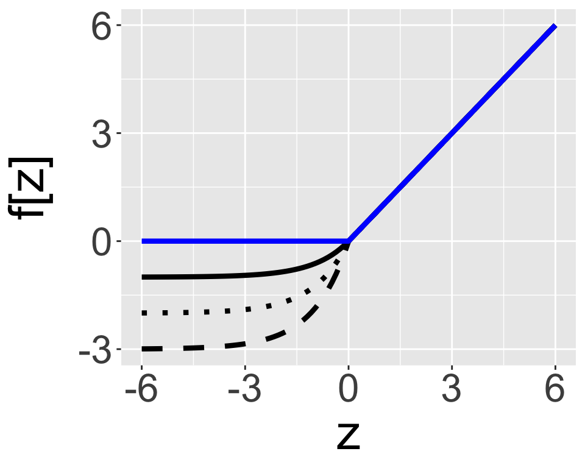

```r
PlotEluRelu <- function(latex = FALSE){
  Fun1 <- function(z){FnElu(z, a = 1)}
  Fun2 <- function(z){FnElu(z, a = 2)}
  Fun3 <- function(z){FnElu(z, a = 3)}
  ggplot() +
    stat_function(fun      = Fun3,
                  color    = "black",
                  size     = LineSize(latex),
                  linetype = DashedLines(latex)) +
    stat_function(fun      = Fun2,
                  color    = "black",
                  size     = LineSize(latex),
                  linetype = DottedLines(latex)) +
    stat_function(fun      = Fun1,
                  color    = "black",
                  size     = LineSize(latex),
                  linetype = "solid") +
    stat_function(fun      = FnRelu,
                  color    = "blue",
                  size     = LineSize(latex),
                  linetype = "solid") +
    scale_x_continuous(breaks = c(-6, -3, 0, 3, 6),
                       limits = c(-6, 6)) +
    scale_y_continuous(breaks = c(-3, 0, 3, 6),
                       limits = c(-3, 6)) +
    labs(x = LabXY(latex)[1],
         y = LabXY(latex)[2]) +
    theme(text = element_text(size = 30)) +
    theme(axis.title.y = element_text(margin = margin(t = 0, r = 15, b = 0, l = 0)))
}
PlotEluRelu()
```

### Swish Versus Relu

We now compare swish with relu (Figure 7 in the manuscript).

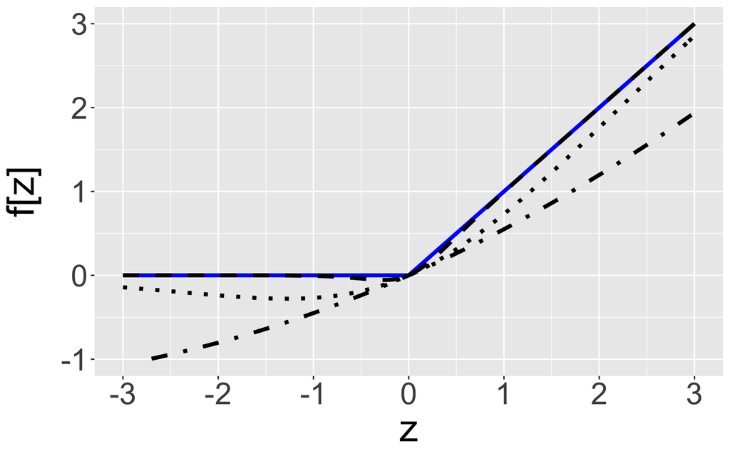

```r
PlotSwishRelu <- function(latex = FALSE, derivative = FALSE){
  if (derivative == TRUE){
    Fun1 = FnSwishD
    Fun2 = function(z){return(1000)}
    upp  = 0
  }
  else{
    Fun1 = FnSwish
    Fun2 = FnRelu
    upp  = 1000
  }
  ggplot() +
    stat_function(fun      = Fun2,
                  color    = "blue",
                  size     = LineSize(latex),
                  linetype = "solid") +
    geom_segment(aes(x = -3, y = 0 + upp, xend = 0, yend = 0 + upp),
                   color    = "blue",
                   size     = LineSize(latex),
                   lineend  = "round",
                   linetype = "solid") +
    geom_segment(aes(x = 0, y = 0 + upp, xend = 0, yend = 1 + upp),
                   color    = "blue",
                   size     = LineSize(latex),
                   lineend  = "round",
                   linetype = "solid") +
    geom_segment(aes(x = 0, y = 1 + upp , xend = 3, yend = 1 + upp),
                   color    = "blue",
                   size     = LineSize(latex),
                   lineend  = "round",
                   linetype = "solid") +
    stat_function(fun = function(z){return(Fun1(z, a = 1))},
                  color    = "black",
                  size     = LineSize(latex),
                  linetype = DottedLines(latex)) +
    stat_function(fun      = function(z){return(Fun1(z, a = 5))},
                  color    = "black",
                  size     = LineSize(latex),
                  linetype = DashedLines(latex)) +
    stat_function(fun = function(z){return(Fun1(z, a = 0.2))},
                  color    = "black",
                  size     = LineSize(latex),
                  linetype = DotDashLines(latex)) +
    scale_x_continuous(breaks = c(-3, -2, -1, 0, 1, 2, 3),
                       limits = c(-3, 3)) +
    scale_y_continuous(breaks = c(-1, 0, 1, 2, 3),
                       limits = c(-1, 3)) +
    labs(x = LabXY(latex      = latex,
                   derivative = derivative)[1],
         y = LabXY(latex      = latex,
                   derivative = derivative)[2]) +
    theme(text = element_text(size = 30)) +
    theme(axis.title.y = element_text(margin = margin(t = 0, r = 15, b = 0, l = 0)))
}
PlotSwishRelu()
```

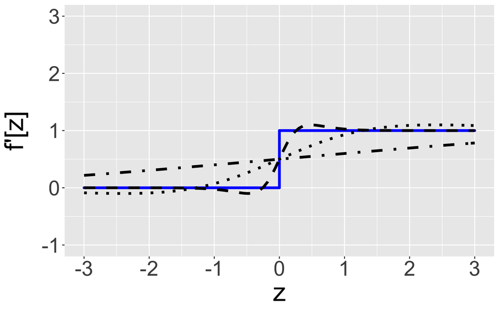

```r
PlotSwishRelu(derivative = TRUE)
```

## Output Ranges of the Functions and Their Derivatives

We now confirm some of the output ranges derived in the manuscript.

### Output Ranges of Logistic’s Second Derivative

We first consider the second derivative of logistic (see Section 2.1.1 and Lemma A.1).

```r
# Function minima and maxima from the manuscript
c(FnLogisticDD(log(2 + sqrt(3))), FnLogisticDD(log(2 - sqrt(3))))
```

```
## [1] -0.09622504  0.09622504
```

```r
# Function minima and maxima from a numerical evaluation
c(optimize(FnLogisticDD, interval=c(-100, 100), maximum = FALSE)$objective, optimize(FnLogisticDD, interval=c(-100, 100), maximum = TRUE)$objective)
```

```
## [1] -0.09622504  0.09622504
```

Hence, the output domain of logistic’s second derivative is $[-0.096225, 0.096225]$, as stated in the paper.

### Output Ranges of Swish and Its Derivatives

We then consider swish and its derivatives (see Section 2.3.3 and Section A.7.5). We first plot and calculate the values $z_1$ and $f_1[z_1]$ in Lemma A.10.

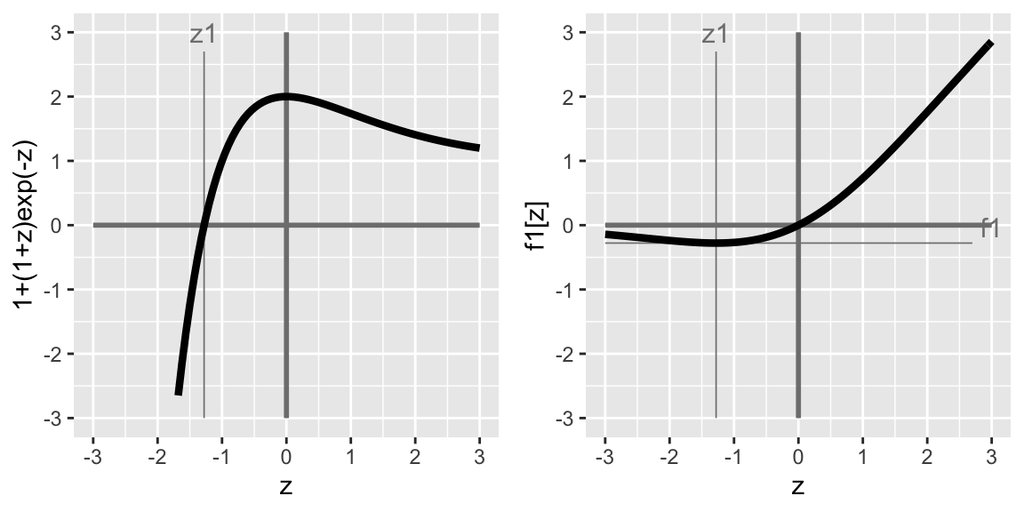

```
## [1] -1.2784645 -0.2784645
```

```r
library("nleqslv")  # find a root of a linear equation
library(gridExtra)  # combine multiple plots
SwishRange <- function(z){
  return(1 + (1 + z) * exp(-z))
}
SwishRangeD <- function(z){
  return(2 - z + (2 + z) * exp(-z))
}
z1 <- nleqslv(-1, SwishRange)$x
f1 <- FnSwish(z = z1, a = 1)
z1P <- nleqslv(1, SwishRangeD)$x
f1P <- FnSwishD(z = z1P, a = 1)
z1N <- nleqslv(-3, SwishRangeD)$x
f1N <- FnSwishD(z = z1N, a = 1)
PlotSwishBounds <- function(derivative = FALSE)
{
  if (derivative){
    Fun1     <- SwishRangeD
    Fun2     <- FnSwishD
    z.value  <- z1P
    f.value  <- f1P
    lab1     <- "z1'"
    lab2     <- "-z1'"
    lab3     <- "f1'"
    lab4     <- "1-f1'"
    lab5     <- "2-z+(2+z)exp(-z)"
    z.valueN <- z1N
    f.valueN <- f1N
  }
  else{
    Fun1     <- SwishRange
    Fun2     <- FnSwish
    z.value  <-  z1
    f.value  <- f1
    lab1     <- "z1"
    lab2     <- ""
    lab3     <- "f1"
    lab4     <- ""
    lab5     <- "1+(1+z)exp(-z)"
    z.valueN <- 0
    f.valueN <- 0
  }
  p1 <- ggplot() +
          geom_segment(aes(x = -3, y = 0, xend = 3, yend = 0),
                       color = "grey50",
                       size  = 1) +
          geom_segment(aes(x = z.value, y = -3, xend = z.value, yend = 2.7),
                       color = "grey50",
                       size  = 0.3) +
          geom_segment(aes(x = z.valueN, y = -3, xend = z.valueN, yend = 2.7),
                       color = "grey50",
                       size = 0.3) +
          geom_segment(aes(x = 0, y = -3, xend = 0, yend = 3),
                       color = "grey50",
                       size  = 1) +
          stat_function(fun  = Fun1,
                        size = LineSize(FALSE)) +
          annotate("text", x = z.value, y = 3, color= "grey50", label = lab1, size = LabelFontSize(FALSE)) +
          annotate("text", x = z.valueN, y = 3, color= "grey50", label = lab2, size = LabelFontSize(FALSE)) +
          scale_x_continuous(breaks = c(-3, -2, -1, 0, 1, 2, 3),
                             limits = c(-3, 3)) +
          scale_y_continuous(breaks = c(-3, -2, -1, 0, 1, 2, 3),
                             limits = c(-3, 3)) +
          labs(x = "z",
               y = lab5)
  p2 <- ggplot() +
          geom_segment(aes(x = -3, y = 0, xend = 3, yend = 0),
                       color = "grey50",
                       size  = 1) +
          geom_segment(aes(x = z.value, y = -3, xend = z.value, yend = 2.7),
                       color = "grey50",
                       size  = 0.3) +
          geom_segment(aes(x = z.valueN, y = -3, xend = z.valueN, yend = 2.7),
                       color = "grey50",
                       size  = 0.3) +
          geom_segment(aes(x = -3, y = f.value, xend = 2.7, yend = f.value),
                       color = "grey50",
                       size  = 0.3) +
          geom_segment(aes(x = -3, y = f.valueN, xend = 2.7, yend = f.valueN),
                       color = "grey50",
                       size  = 0.3) +
          geom_segment(aes(x = 0, y = -3, xend = 0, yend = 3),
                       color = "grey50",
                       size  = 1) +
          stat_function(fun  = Fun2,
                        size = LineSize(FALSE)) +
          annotate("text", x = z.value, y = 3, color= "grey50", label = lab1, size = LabelFontSize(FALSE)) +
          annotate("text", x = z.valueN, y = 3, color= "grey50", label = lab2, size = LabelFontSize(FALSE)) +
          annotate("text", x = 3, y = f.value + 0.25, color= "grey50", label = lab3, size = LabelFontSize(FALSE)) +
          annotate("text", x = 3, y = f.valueN - 0.25, color= "grey50", label = lab4, size = LabelFontSize(FALSE)) +
          scale_x_continuous(breaks = c(-3, -2, -1, 0, 1, 2, 3),
                             limits = c(-3, 3)) +
          scale_y_continuous(breaks = c(-3, -2, -1, 0, 1, 2, 3),
                             limits = c(-3, 3)) +
          labs(x = "z",
               y = "f1[z]")
  grid.arrange(p1, p2, heights = c(1), ncol = 2)
  print(c(z.value, f.value))
}
PlotSwishBounds(derivative = FALSE)
```

We find that $z_1\approx$-1.2784645 and $f_1[z_1]\approx$-0.2784645.

We can now confirm the dependencies of the minimizers and minima of swish on $a$ stated in the manuscript.

```r
SwishTest <- function(a = 1, derivative = "none"){
  if (derivative == "none"){
    za <- optim(0, FnSwish, a = a)$par
    fa <- FnSwish(z = za, a = a)
    return(c(z1 / za, f1 / fa))
  }
  if (derivative == "first"){
    zaN <- optim(0, FnSwishD, a = a)$par
    faN <- FnSwishD(z = zaN, a = a)
    return(c(z1N / zaN, f1N / faN))
  }
}
a1 <- 0.5; a2 <- 1; a3 <- 2
c(SwishTest(a1) / a1,SwishTest(a2) / a2 ,SwishTest(a3) / a3)   # should all be close to 1
```

```
## [1] 1 1 1 1 1 1
```

We now plot and calculate the values $z_1'$ and $f_1[z_1']$ in Lemma A.11.

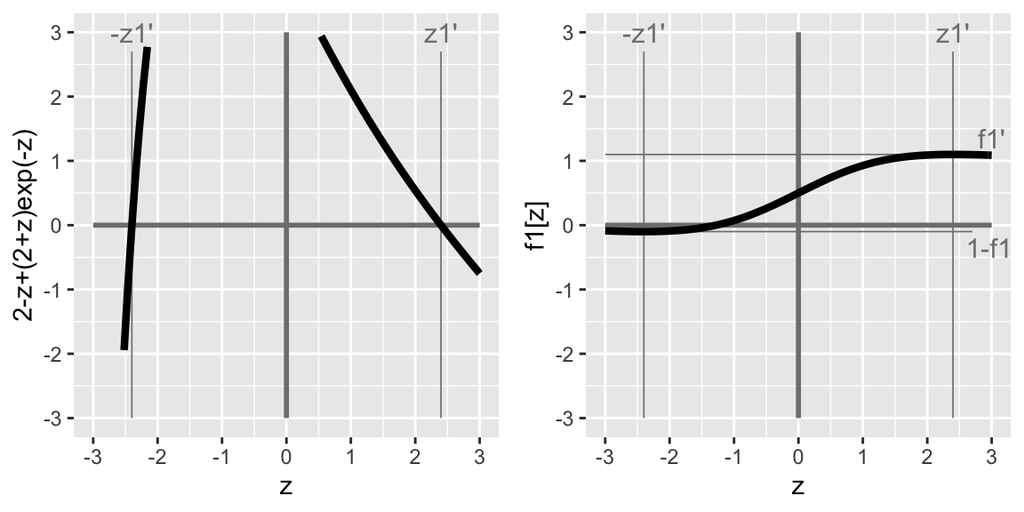

```
## [1] 2.399357 1.099839
```

```r
PlotSwishBounds(derivative = TRUE)
```

We find that $z_1'\approx$ 2.3993573 and $\dot f_1[z_1']\approx$ 1.0998393.

We can also verify that the minimizers scale with $1/a$ and the minima are constant in $a$.

```r
c(SwishTest(a1, derivative = "first")[1] / a1,
  SwishTest(a1, derivative = "first")[2],
  SwishTest(a2, derivative = "first")[1] / a2,
  SwishTest(a2, derivative = "first")[2],
  SwishTest(a3, derivative = "first")[1] / a3,
  SwishTest(a3, derivative = "first")[2])  # should all be close to 1
```

```
## [1] 1.000058 1.000000 1.000058 1.000000 1.000058 1.000000
```

We finally turn to the second derivatives. We first confirm the ranges stated in the manuscript.

```r
Fun1 <- function(z){FnSwishDD(z, a = a1)}
Fun2 <- function(z){FnSwishDD(z, a = a2)}
Fun3 <- function(z){FnSwishDD(z, a = a3)}
# Maxima
cPP <- optim(0, function(z){FnSwishDD(z, a = 1)}, control=list(fnscale=-1))$value  # last argument ensures maximization
print(cPP)
```

```
## [1] 0.5
```

```r
c(optim(0, Fun1, control=list(fnscale=-1))$value / a1,
  optim(0, Fun2, control=list(fnscale=-1))$value / a2,
  optim(0, Fun3, control=list(fnscale=-1))$value / a3) / cPP  # should all be close to 1
```

```
## [1] 1 1 1
```

```r
# Minima
cNN <- optim(0, function(z){FnSwishDD(z, a = 1)})$value
print(cNN)
```

```
## [1] -0.03691437
```

```r
c(optim(0, Fun1)$value / a1,
  optim(0, Fun2)$value / a2,
  optim(0, Fun3)$value / a3) / cNN  # should all be close to 1
```

```
## [1] 1 1 1
```

We confirm that the maxima of swish’s second derivative are 0.5$\cdot a$, and the minima are approximately -0.0369144$\cdot a$.

We now illustrate the findings with a plot.

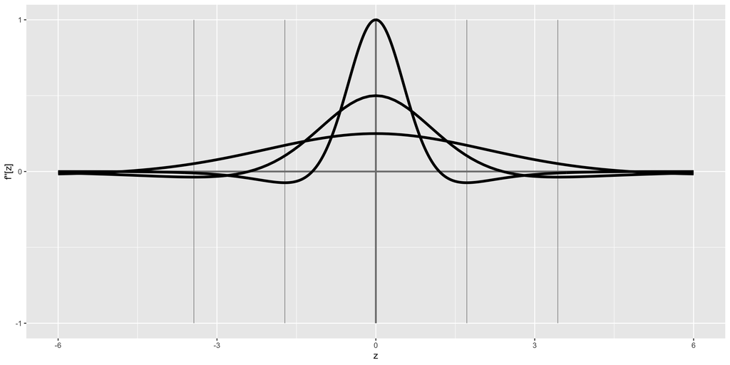

```r
argmin1 <- optim(0, Fun1)$par
argmin2 <- optim(0, Fun2)$par
argmin3 <- optim(0, Fun3)$par
ggplot() +
  geom_segment(aes(x = -6, y = 0, xend = 6, yend = 0),
               color = "grey50",
               size  = 1) +
  geom_segment(aes(x = 0, y = -1, xend = 0, yend = 1),
               color = "grey50",
               size  = 1) +
  geom_segment(aes(x = argmin1, y = -1, xend = argmin1, yend = 1),
               color = "grey50",
               size  = 0.3) +
  geom_segment(aes(x = argmin2, y = -1, xend = argmin2, yend = 1),
               color = "grey50",
               size  = 0.3) +
  geom_segment(aes(x = argmin3, y = -1, xend = argmin3, yend = 1),
               color = "grey50",
               size  = 0.3) +
  geom_segment(aes(x = -argmin1, y = -1, xend = -argmin1, yend = 1),
               color = "grey50",
               size  = 0.3) +
  geom_segment(aes(x = -argmin2, y = -1, xend = -argmin2, yend = 1),
               color = "grey50",
               size  = 0.3) +
  geom_segment(aes(x = -argmin3, y = -1, xend = -argmin3, yend = 1),
               color = "grey50",
               size  = 0.3) +
  stat_function(fun  = Fun1,
                size = LineSize(FALSE)) +
  stat_function(fun  = Fun2,
                size = LineSize(FALSE)) +
  stat_function(fun  = Fun3,
                size = LineSize(FALSE),
                n    = 1000) +  #for a smoother plot
  scale_x_continuous(breaks = c(-6, -3, 0, 3, 6),
                     limits = c(-6, 6)) +
  scale_y_continuous(breaks = c(-1, 0, 1),
                     limits = c(-1, 1)) +
  labs(x = "z",
       y = "f''[z]")
```